# Order of Breezing VS Breeze Up Performance

Henry Baugniet

04/02/2021

### Introduction

We are looking to establish whether there is a correlation between the order a horse breezes and its breeze-up performance. Furthermore, we want to look at whether the breeze-up performance is indicative of future performance.

### Data and Environment

Information regarding the following variables was collected from 2017-2020 regarding horses sold at breeze-up sales:

- The sale at which a horse was sold
- The date of sale
- The seller of the horse
- The price the horse fetched
- The breeze time of the horse (s)
- The order in which the horses breezed

Analysis will be carried out in R relying heavily on the following packages:

- data.table
- ggplot

There are other packages that are used and these are all found in libraries.R

### Glossary of Terms

1. pctSeqBreeze <- The position of the horse in the breeze order as a percentage relative to that particular sale.
2. SeqBucket <- The bucket assigned to a horse based on it’s breeze order position.
3. Time2f.Vmed <- The 2 furlong time of a horse relative to the median time for that breeze in seconds.
4. ORFmax <- The maximum official rating that a horse has achieved follwing the sale. Where, O = Official Rating. RF = sourced from Raceform (RF) and max is the highest rating achieved.

# Index

### Part 1: Is there a correlation between Breeze Order and Breeze Time?

We want to find out whether there is any correlation between the position in the order that a horse breezes in and the time in which it runs the breeze. Firstly, I will generate a summary table. I have grouped the horses into buckets by whether they breeze in the first, second or third segment of the horses that breeze. I have generated statistics based on these buckets. The statistics use time as Time2f.Vmed which is defined in the gloassry. I have also included a histogram showing that the horses are evenly distributed amongst the breeze order.

| BucketNo. | Min | Max | Mean | Median | IQR |
| --- | --- | --- | --- | --- | --- |
| 1 | -1.425 | 1.994 | -0.039 | -0.118 | 0.730 |
| 2 | -1.393 | 1.994 | 0.005 | -0.086 | 0.759 |
| 3 | -1.462 | 1.992 | 0.109 | 0.044 | 0.840 |

###### Figure 1.1: A summary table showing time statistics for each order bucket with 1 being the earliest to Breeze and 3 being the latest.

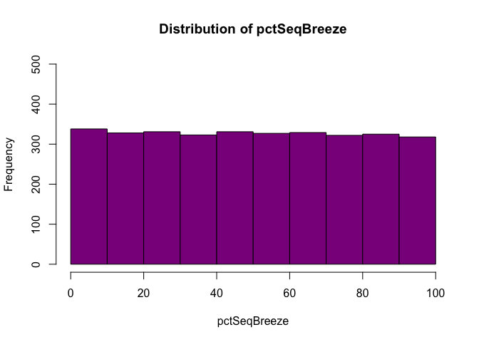

###### Figure 1.2: A histogram showing the distribution of pctBreezeOrder which is the percentage breeze order.

This shows that we have an equal number of horses running in each proportion of the breeze which is what we would hope for from our data.

From looking at the mean and median statistics it appears that horses that breeze earlier in the order have a lesser breeze time than those that run later. To test that this difference is significant I will conduct some t-tests on the time differences between the buckets. Since we have a hypothesis about the direction of the effect, we will conduct a one-tailed t-test. I test the difference between bucket 1 and bucket 2, between bucket 1 and bucket 3 and finally between bucket 2 and bucket 3.

| Buckets Tested | t Value | Degrees Of Freedom | p Value |
| --- | --- | --- | --- |
| Bucket1 and Bucket2 | -1.740 | 2174.809 | 0.041 |
| Bucket1 and Bucket3 | -5.619 | 2168.079 | 0.000 |
| Bucket2 and Bucket3 | -3.938 | 2166.363 | 0.000 |

###### Figure 1.3: A table showing a welch ttest testing the difference in 2 furlong time versus the median between order buckets.

We can see from the P values that there is a significant difference in breeze times for the horses and that the probility of this occurring due to chance is well below our threshold p value of p = 0.05. This probability is the smallest for the difference between bucket 1 and bucket 3 as expected.

I have also included a linear regression which allows a more visual interpretation of the data. Here I have not divided the data up in buckets. I still use the 2 furlong time vs the median 2 furlong time (s).

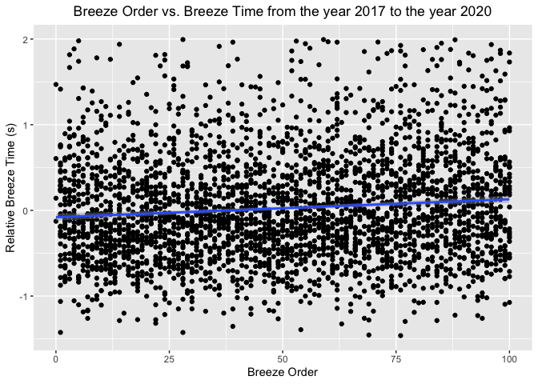

[output not shown]

###### Figure 1.4: A univariate linear regression plot and a data table containing the statistics for the linear regression with Breeze order as the explanatory variable and time vs the median as the response variable.

This linear regression shows that there is a lot of noise and that in fact the correlation could be a result of this. We will therefore have to be careful using this assumption in our following analysis.

Assuming that there is a correlation between breeze order and breeze time. There are a number of things that could explain this.

1. Firstly, the ground throughout the day worsens as more and more horses run and this will have a significant impact on the speed at which the horse is able to run 2 furlongs
2. Secondly, and more to our interest, are consignors pushing for their best horses to run earlier in the day and further, can this be used to predict the future ability of a horse?

This study will discuss the ability of breeze order to predict future ability of a horse. Specifically, this leads us onto the next question.

### Part 2: Is there a correlation between Breeze Order and max future rating?

I will now look at whether there is a correlation between the order in which a horse breezes and its future max rating. As in the last question, to start with, I have generated a summary table so that we can get a general idea of any correlation and the direction of the effect. We talk about max future rating as ORF max, this is defined in the glossary. The following table aims to show whether breeze order seems to have any correlation with ORFmax.

| BucketNo. | Min | Max | Mean | Median | IQR |
| --- | --- | --- | --- | --- | --- |
| 1 | 4 | 121 | 73.299 | 73.0 | 25.00 |
| 2 | 4 | 114 | 69.884 | 71.0 | 25.00 |
| 3 | 5 | 119 | 69.412 | 69.5 | 22.25 |

###### Figure 2.1: A table showing ORFmax for each bucket by breeze order with 1 being the earliest to Breeze and 3 being the latest.

It is convenient to also include a linear regression plot for a visual interpretation of the data and the direction of the trend, if any.

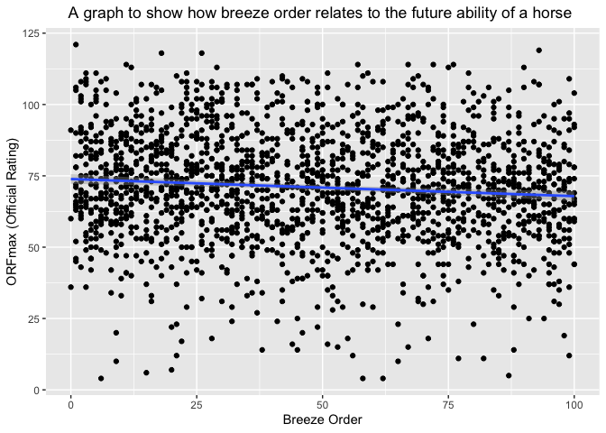

| Term | Estimate | Standard Error | Regression Statistic | p Value |
| --- | --- | --- | --- | --- |
| Intercept | 73.87072 | 0.8485 | 87.058 | 0.00000000 |
| Explanatory Variable | -0.05978 | 0.0150 | -3.987 | 0.00006951 |

###### Figure 2.2: A data table containing the statistics for a linear regression with Breeze order as the explanatory variable and ORFmax response variable.

From looking at the above results we can see that there does appear to be the general trend that horses running later on in the breeze have a lower future max rating. We can also see that this correlation is not as pronounced as that between breeze time and future max rating.

I will now conduct a ttest in order to determine whether this trend that we can see is significant.

| Buckets Tested | t Value | Degrees Of Freedom | p Value |
| --- | --- | --- | --- |
| Bucket1 and Bucket2 | 3.216 | 1290.152 | 0.001 |
| Bucket1 and Bucket3 | 3.710 | 1276.594 | 0.000 |
| Bucket2 and Bucket3 | 0.436 | 1222.827 | 0.331 |

###### Figure 2.3: A welch ttest testing the difference in ORFmax between order buckets.

Upon ttesting the result for significance we see that there is a significant difference between the first and second buckets but not between the second and third. This suggests that breeze order may have some value to us and is worth investigating further. However, there are a few adjustments that we can make in order to generate some more valuable metadata. This is what we will do in the next question which involves generating an order score for the horses and using this rather than simply the percentage position.

### Part 3: How do we generate a more representative breeze order relative to consignor sway?

The order of their own horses breezing is determined by the consignor. It interesting to look at whether there is any correlation between the size of the consignor and their average breezing position as if we adjust for this we might get a more accurate measure of how the horses are ordered relative to their predetermined future ability.

Here I have defined a small consignor as one that has had less than 25 horses at sale since we began collecting order data. To account for the different number of horses that run at each breeze I have used a percentage relative to the highest position at that sale to describe the breeze position.

| Small Seller | Average Breeze Position |
| --- | --- |
| FALSE | 47.250 |
| TRUE | 57.813 |

###### Figure 3.1: A data table comparing average breeze position for small sellers and large sellers.

When comparing the average breeze position for a small seller against a larger seller we see that there is a clear difference between the average position of a small seller and a larger seller.

| Data Name | t Value | Degrees of Freedom | p Value |
| --- | --- | --- | --- |
| smallSellerSeq and largeSellerSeq | 9.353 | 1579.019 | 0 |

###### Figure 3.2: A t-test to compare the difference in race position for small and large sellers

The t-test shows that this result is significant.

It would also be interesting to see if there are any particular consignors that stand out as having a more significant influence over position.

| Seller | Average Breeze Position | Total No. Sold |
| --- | --- | --- |
| Aguiar Bloodstock | 45.147 | 34 |
| Ardglas Stables | 38.652 | 46 |
| Ballinahulla Stables | 37.970 | 33 |
| Ballycullen Stables | 52.133 | 30 |
| Bansha House Stables | 60.378 | 119 |
| Bloodstock Connection | 45.091 | 33 |
| Brown Island Stables | 37.359 | 78 |
| Bushy Park Stables | 60.481 | 27 |
| CAJ Stables | 35.385 | 39 |
| Derryconnor Stud | 55.040 | 50 |
| Egmont Stud | 49.855 | 76 |
| Gaybrook Lodge | 31.602 | 83 |
| Grove Stud | 39.078 | 90 |
| Horse Park Stud | 44.507 | 69 |
| Hyde Park Stud | 56.339 | 112 |
| Katie Walsh | 40.538 | 39 |
| Kilminfoyle House Stud | 55.062 | 32 |
| Knockanglass Stables | 58.452 | 177 |
| Knockgraffon Stables | 61.588 | 34 |
| Lackendarra Stables | 63.172 | 29 |
| Longway Stables | 49.138 | 87 |
| Lynn Lodge Stud | 46.417 | 36 |
| Malcolm Bastard | 44.024 | 41 |
| Mayfield Stables | 42.433 | 90 |
| Meadow View Stables | 36.603 | 68 |
| Mocklershill | 39.883 | 274 |
| Oak Farm Stables | 34.806 | 36 |
| Oak Tree Farm | 41.930 | 43 |
| Powerstown Stud | 48.176 | 68 |
| Shanaville Stables | 74.400 | 30 |
| Sherbourne Lodge | 69.280 | 82 |
| Star Bloodstock | 29.903 | 62 |
| TallyHo Stud | 46.650 | 180 |
| Yeomanstown Stud | 48.553 | 47 |
| Small Sellers | 57.813 | 898 |

###### Figure 3.3: A data table comparing small sellers to larger sellers

This table shows that there are obviously some consignors that have achieved earlier average breeze positions over the years and this would be an interesting area to explore in future research.

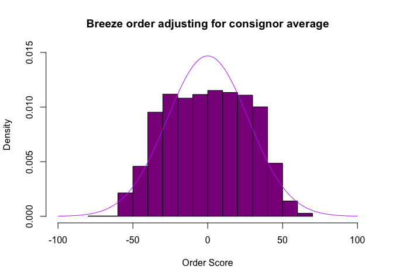

###### Figure 3.4: A histogram showing the distribution of our breeze score.

This plot shows the breeze score with a normal distribution centered around a score 0 overlayed. The normal distribution is an okay fit.

### Linear Regression adjusted for consignor bias

I have given a position score to each horse based on the average position for that consignor I have put all small consignors (those who have sold less than 25 horses) together when calculating this adjustment.

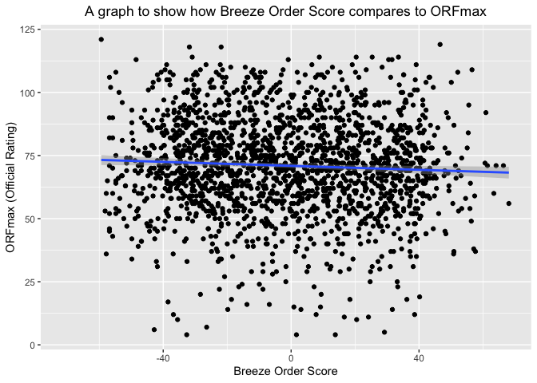

| Term | Estimate | Standard Error | Regression Statistic | p Value |
| --- | --- | --- | --- | --- |
| Intercept | 70.91491 | 0.43538 | 162.882 | 0.00000 |
| Explanatory Variable | -0.03939 | 0.01603 | -2.458 | 0.01405 |

The higher p value here (compared to regression with pctSeqBreeze) suggest that orderScore is actually not as good a predictor of ORFmax as pctSeqBreeze. Therefore, for the rest of our analysis we will use pctSeqBreeze where neccessary.

### Part 4: Does breeze order give us any additional information?

The ultimate question that this study is asking is; if we look at the breeze time of a horse does having breeze order give us any additional information towards predicting the future value of the horse?

It is therefore important to try to separate order and breeze time, we have shown that they both have value in terms of predicting the future value of a horse, we now need to test for multi-collinearity in order to see if they have value as individual variables.

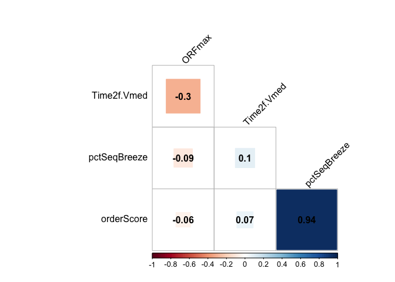

###### Figure 4.1: A correlation matix comparing time, absolute breeze order, adjusted breeze order and ORFmax.

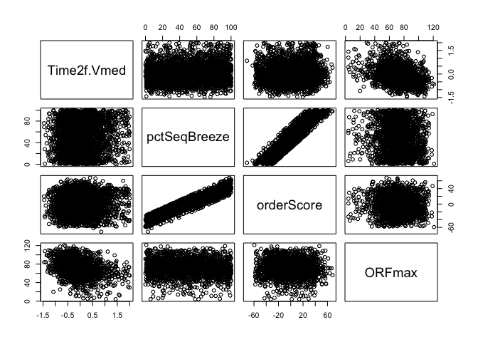

###### Figure 4.2: A pairwise scatter plot

From the correlation matrix and the plot we see again that pctBreezeOrder is a better value than orderScore for determining the future ability of a horse.

From the correlation matrix in part 4 it appears that the correlations between time and pctBreezeSeq is low enough that multicollinearity wont be too much of an issue.

```
## [1] "VIF = 1.10597496056056"
```

###### Variance Inflation Factor

We usually only consider multi-collinearity to be a problem when VIF > 10. Therefore, we assume that multi-collinearity is not a problem and can move onto the next section.

### Part 5: What is the best model for determining ORFmax?

As we have seen that pctBreezeSeq is a better measure than order score we will use this for the rest of the analysis. Here we aim to determine whether we actually gain any value through the use of pctSeqBreeze. By this I mean does having this extra variable actually add any value to our model? There, is no point in adding a variable to our model if it doesn’t improve it. Is a model involving both time and pctSeqBreeze better than one that only involves time.

In our various models:

- x1 - pctSeqBreeze
- x2 - time

#### y = m1x1 + c

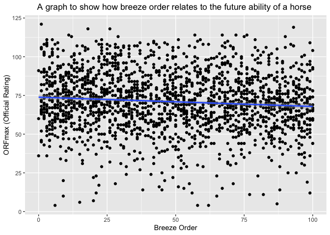

| Term | Estimate | Standard Error | Regression Statistic | p Value |
| --- | --- | --- | --- | --- |
| Intercept | 73.87072 | 0.8485 | 87.058 | 0.00000000 |
| Explanatory Variable | -0.05978 | 0.0150 | -3.987 | 0.00006951 |

###### Figure 5.1: A regression between predictor pctSeqBreeze and ORFmax.

Our p-value of 0.00007 suggests that this negative trend is significant and pctSeqBreeze has value wrt to predicting ORFmax.

#### y = m2x2 + c

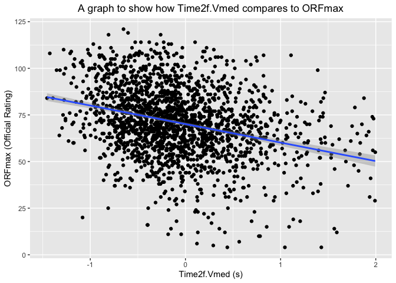

| Term | Estimate | Standard Error | Regression Statistic | p Value |
| --- | --- | --- | --- | --- |
| Intercept | 70.102 | 0.4197 | 167.05 | 0.000e+00 |
| Explanatory Variable | -9.932 | 0.7134 | -13.92 | 4.841e-42 |

###### Figure 5.2: A regression between predictor Time2f.Vmed and ORFmax.

Our p-value of 4.841e-42 suggests that this negative trend is significant and Time2f.Vmed has value wrt predicting ORFmax.

We have seen that both factors when used on their own have significant value in predicting the future ability of a horse. However, we want to know if when they are used together this provides a better model than using just Time on its own.

#### y = m1x1 + m2x2 + c

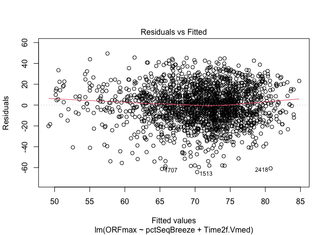

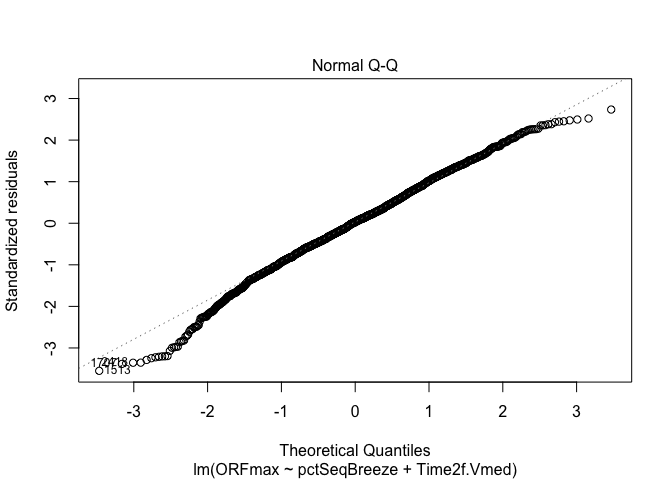

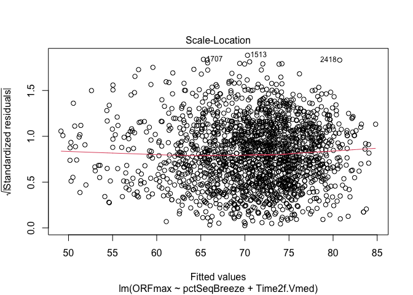

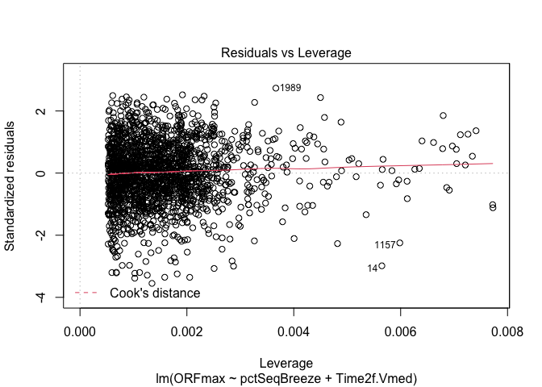

###### Figure 5.3: A series of plots to help determine the effectiveness of the model when modelling ORFmax from predictors pctSeqBreeze and Time2f.Vmed.

We can see from our residuals vs fitted plot that there is no evidence of the fan shape characteristic of heteroscedasticity. This would mean that as the fitted values increase the variance of the residuals also increases. This does not appear to be the case.

The next plot is the QQ-plot. Though most of the points seem to fall on the line which indicates that our residuals come from a normal distribution, there are some points that stray from the line in the lower and upper quantiles of the plot. It is possible that these points do not come from a normal distribution, but most of our points seem to come from a normal distribution so there is not a lot to worry about here.

The third plot created is the scale-location plot. This plot is similar to the residual plot, but uses the square root of the standardized residuals instead of the residuals themselves. This makes trends in residuals more evident.

Finally, we see the leverage plot. This plot graphs the standardized residuals against their leverage. It also includes the Cook’s distance boundaries. Any point outside of those boundaries would be an outlier in the x direction. Since we cannot even see the boundaries on our plot, we can conclude that we have no outliers.

|  | Est. | S.E. | t val. | p |
| --- | --- | --- | --- | --- |
| (Intercept) | 72.083 | 0.821 | 87.799 | 0.000 |
| pctSeqBreeze | -0.040 | 0.014 | -2.806 | 0.005 |
| Time2f.Vmed | -9.733 | 0.716 | -13.601 | 0.000 |

###### Figure 5.4: The coefficient table for the multivariate regression

|  | 2.5 % | 97.5 % |
| --- | --- | --- |
| (Intercept) | 70.473 | 73.693 |
| pctSeqBreeze | -0.069 | -0.012 |
| Time2f.Vmed | -11.137 | -8.330 |

###### Figure 5.5: The confidence intervals for the multivariate regression

| F(2, 1910) | R-sqd | Adj-R-sqd |
| --- | --- | --- |
| 101.2061 | 0.0958 | 0.0949 |

###### Figure 5.6: The model fit statistics for the multivariate regression.

Refer to modellingORFmax.Rmd for some additional information looking into the best models. This makes it look like the best model is the one that includes both pctSeqBreeze and Time2f.Vmed. However, even this model does not do as good a job as measuring price. There are clearly other factors that people are paying for and can observe.

# Conclusion of Initial Study and Areas for Future Research

#### Conclusion

The research into the correlation between breeze order and breeze time must be interpreted with caution. There is clearly a lot of noise in the scatter plot (with linear regression) looking into the correlation between the two variables. The correlation that we are seeing may just be due to our large number of data points. However, I don’t believe this first section to have no value, so have left it in.

The subsequent sections:

- In conclusion, we have found that breeze order can be used to improve our initial time only model to predict the ORFmax of a horse.
- This means that a horse running the same breeze time as another but later in the order is likely a worse horse.
- This hints at the fact that consignors are putting their better horses earlier in the order and that this involves more than just how fast they are capable of running the breeze.
- It will may useful to add breeze order to our current model for predicting ORFmax. Before doing this we must check that pctBreezeOrder is still significant when tested in combination with the current model. The current model predicts a horses future value using breeze time and a number of other factors.

#### Future Research

In the future it will be interesting to see how our findings relate to the prices that people end up paying for particular horses. It could be the case that people are placing too much emphasis on the Breeze Time of a horse and actually paying more for a horse than it is worth, purely due to this. We will need to somehow model the future value of a horse using ORFmax. I attempt to do this in another project “postPresentation.Rmd”.

It will also be useful to look at a similar question about breeze order but on a consignor level. An individual consignor gets allotted spots in the order and then gets to pick which horse of theirs they place in each of these spots. Therefore, a consignor picks completely the order of their own horses. If it is the case that a particular consignor always places their horses in the order that they think is representative of their future ability then this could be significant to us in predicting the future value of a horse. However, it is likely that different consignors have different tactics and that we only have enough data to elucidate the strategies of the largest consignors. Smaller consignors may not have sold enough horses to be able to tell this kind of thing.

We are also provided with a good basis for spotting edge cases. If a large consignor has placed a horse early in their order but it then runs a slow breeze time we might be inclined to underestimate the value of the horse if we do not take into account the fact that the consignor has chosen to place the horse early in their order. Does the consignor know something that the breeze time does not about the future ability of this particular horse. We may therefore be able to get good value on a horse that runs a slow breeze time through using the intuition of the consignor to uncover variables unknown to us.